# Classification of Multiple Sclerosis (MS)

with Machine Learning Methods

Zhongmao Liu

This tutorial aims to provide a frame work of doing binary classification analysis with machine learning methods and with multi-omics data. The data and analysis accord with a published paper (Cantoni et al. 2022), however some details such as parameter tuning may differ.

For more detail of code, check the ‘code_MS’ folder. Notice: tuning grids and parameter setting should be adjusted according to specific projects!

# 1 The multi-omics data

## 1.1 Period A Data

The integrated multi-omics data collected at period A contains 52 subjects/samples, where otu data has 46 samples, blood data has 50 samples, immune data has 50 samples, meta data has 52 samples.

- The 1st col is “id” (sample name)
- The 2ed col is “Diagnosis”: 26 MS (full name is RRMS) and 26 Control.
- The 3-8859th columns (8857 features) are from “blood” data: serum metabolites from “mz1” to “mz8857”
- The 8860-8902th columns (43 features) are from “meta” data: meta+nutrition features from “Age.at.collection” to “Sugar.Sweetened.Soft.Drinks”.
- The 8903-8944th columns (42 features) are from “immune” data: immune cell populations and cytokine profiles from “X.HLADR.pos.active.Myeloid.Cells.Panel4” to “CD4..Tregs.Panel5”
- The 8945-9728th columns (784 features) are from “otu” data.

## 1.2 Data pre-processing

Centered log ratio transformation is conducted to otu data.

# 2 Diagnosis of MS with period A data

## 2.1 Object

- Use multi-omics data to make classification on MS / Control.
- Find which features are the most useful for making MS diagnosis.

## 2.2 Method

**Train machine learning models to make classification on MS / Control**

Repeatedly run S=100 repeats of the following process:

- Divide the period A data into train data (80% samples) and test data (10 samples).
- With train data, train machine learning models:
  - Conduct marginal screening to all features.
    - The tests involved are wilcoxon test for integer features; t-test or wilcoxon test for continuous features depending on normality; Fisher’s exact test for categorical features.
    - Besides, Sex does not attend marginal screening and is always involved in model fitting.
    - The p values are adjusted by false discovery rate (fdr) control.
    - The screening threshold is p < 0.05 for blood data, and p < 0.1 for genus, immune, meta data.
  - Fill in NAs.
    - NAs from categorical features are replaced by a new class called ‘G_NA’.
    - NAs from numerical features are replaced by group mean (MS / Control) for train data; by mean for test data.
  - Change multi-class categorical features to dummy variables.
  - Fit models.
    - The four competing methods are random forest (Liaw and Wiener 2002), XGBoost (Chen et al. 2023), elastic net logistic regression (Friedman, Hastie, and Tibshirani 2010), elastic net svm (Yi and Zeng 2018). Parameter tuning is conducted through leave-one-out CV with classification error treated as model selection criteria.
    - More details of tuning grids for each method can be found from the ‘Code_MS’ folder.
- Report prediction performance in test data
  - accuracy (1 - error)
  - ROC
  - AUC

**Find which features are useful for making MS diagnosis**

- Select the method with the highest out-of-sample prediction accuracy.
- Report feature importance calculated by the selected method.
  - XGBoost: Gain
  - RF: mean decrease gini
  - ENL and SVM: frequency of selection

## 2.3 Result

### 2.3.1 Prediction accuracy on test data

RF achieves the highest out-of-sample prediction accuracy.

Table 2.1: Prediction Accuracy on test data

|  | AVE.TPR | AVE.TNR | AVE.FNR | AVE.FPR | Accuracy.AVE | Accuracy.sd |
| --- | --- | --- | --- | --- | --- | --- |
| XGBoost | 0.880 | 0.822 | 0.120 | 0.178 | 0.851 | 0.110 |
| RF | 0.912 | 0.850 | 0.088 | 0.150 | 0.881 | 0.092 |
| ENL | 0.904 | 0.830 | 0.096 | 0.170 | 0.867 | 0.104 |
| SVM | 0.860 | 0.794 | 0.140 | 0.206 | 0.827 | 0.131 |

### 2.3.2 Feature importance from train data

Since RF achieves the best prediction accuracy, we report the feature importance table generated with RF.

| Feature | Sum.MeanDecreaseGini | Marginal.Frequency |
| --- | --- | --- |
| mz4 | 214.354 | 100 |
| mz3 | 172.742 | 100 |
| mz1 | 164.907 | 100 |
| mz2 | 147.721 | 100 |
| mz6 | 118.905 | 100 |
| mz5 | 98.403 | 100 |
| mz10 | 91.818 | 100 |
| mz143 | 78.04 | 94 |
| mz9 | 70.892 | 100 |
| mz14 | 53.131 | 68 |

[output cut: 373 more lines]

Figure of the top 20 important features by RF.

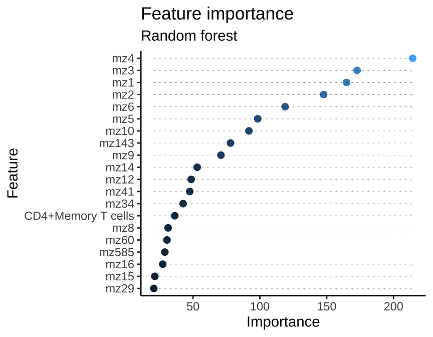

### 2.3.3 ROC Plot

Mean ROC curve with annotation of median AUC & 90% AUC CI.

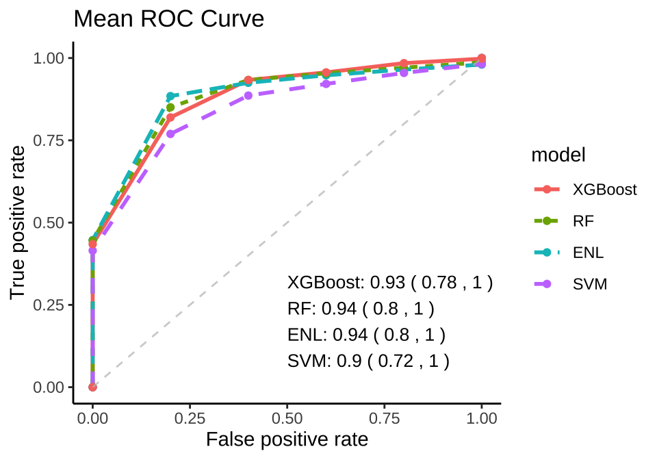

# Reference

Cantoni, Claudia, Qingqi Lin, Yair Dorsett, Laura Ghezzi, Zhongmao Liu, Yeming Pan, Kun Chen, et al. 2022. “Alterations of Host-Gut Microbiome Interactions in Multiple Sclerosis.” *EBioMedicine* 76: 103798.

Chen, Tianqi, Tong He, Michael Benesty, Vadim Khotilovich, Yuan Tang, Hyunsu Cho, Kailong Chen, et al. 2023. *Xgboost: Extreme Gradient Boosting*. https://CRAN.R-project.org/package=xgboost.

Friedman, Jerome, Trevor Hastie, and Robert Tibshirani. 2010. “Regularization Paths for Generalized Linear Models via Coordinate Descent.” *Journal of Statistical Software* 33 (1): 1–22. https://doi.org/10.18637/jss.v033.i01.

Liaw, Andy, and Matthew Wiener. 2002. “Classification and Regression by randomForest.” *R News* 2 (3): 18–22. https://CRAN.R-project.org/doc/Rnews/.

Yi, Congrui, and Yaohui Zeng. 2018. *sparseSVM: Solution Paths of Sparse High-Dimensional Support Vector Machinewith Lasso or Elastic-Net Regularization*. https://CRAN.R-project.org/package=sparseSVM.